# Fantasy Baseball Model Hitting

Darshan Patel

2/26/2022

```r
library(stringr)
library(tidyverse)
library(sqldf)
library(rvest)
library(stringi)
library(skimr)
library(ggplot2)
library(dplyr)
library(tidyverse)
library(caret)
library(xgboost)
library(Matrix)
library(vtreat)
```

https://cran.r-project.org/web/packages/ParBayesianOptimization/vignettes/tuningHyperparameters.html https://www.kaggle.com/silverstone1903/xgboost-grid-search-r/notebook https://www.kaggle.com/pelkoja/visual-xgboost-tuning-with-caret

```r
data(LahmanData, package="Lahman")
str(LahmanData) #take a look at the data

LahmanData$file #gives names of all files

#Reading in Data up to 2020, 2021 data is scraped in another notebook from MLB.com
    data(   AllstarFull   , package="Lahman")

  data(  Appearances        , package="Lahman")

  data( AwardsManagers     , package="Lahman")

  data(AwardsPlayers    , package="Lahman")
data(AwardsShareManagers, package="Lahman")
data(AwardsSharePlayers, package="Lahman")
 data(   Batting           , package="Lahman")
data(    BattingPost        , package="Lahman")
data( CollegePlaying , package="Lahman")
data(  Fielding           , package="Lahman")
 data( FieldingOF       , package="Lahman")
data(  FieldingPost       , package="Lahman")

  data(  HomeGames         , package="Lahman")
  data(  HallOfFame         , package="Lahman")
 data( Managers        , package="Lahman")
 data(  ManagersHalf     , package="Lahman")
  data( Master             , package="Lahman")
  data(  Parks         , package="Lahman")
data(  Pitching         , package="Lahman")
data(  PitchingPost     , package="Lahman")
 data(Salaries        , package="Lahman")
  data(  Schools            , package="Lahman")
 data( SeriesPost      , package="Lahman")
data(  Teams           , package="Lahman")
 data( TeamsFranchises   , package="Lahman")
    data(TeamsHalf  , package="Lahman")


        data(People  , package="Lahman")
```

### 2015+ Models

[output not shown]

[output cut: 990 more lines]

#### 2021 Data - Fantasy Pros

```r
#HMM this is missing a few stats found in Lahman, but we can use VBR as a pseudo scoring mechanism
URL2021_Actual = read_html('https://www.fantasypros.com/mlb/stats/hitters.php?range=2021&page=ALL')


batting_2021 =
  URL2021_Actual %>%
  html_nodes(xpath ='//*[@id="main-container"]/div/div/div/div[6]') %>%
  html_table()


batting_2021 = batting_2021[[1]]

batting_2021
```

#### 2021 Data - MLB

```r
#Additional 2021 Stats-Current Players
Adv_stats1 = read_html('https://www.mlb.com/stats/plate-appearances?expanded=true&playerPool=ALL_CURRENT')
Adv_stats2 = read_html('https://www.mlb.com/stats/plate-appearances?expanded=true&page=2&playerPool=ALL_CURRENT')

Adv_stats3 = read_html('https://www.mlb.com/stats/plate-appearances?expanded=true&page=3&playerPool=ALL_CURRENT')

Adv_stats4 = read_html('https://www.mlb.com/stats/plate-appearances?expanded=true&page=4&playerPool=ALL_CURRENT')

Adv_stats5 = read_html('https://www.mlb.com/stats/plate-appearances?expanded=true&page=5&playerPool=ALL_CURRENT')

Adv_stats6 = read_html('https://www.mlb.com/stats/plate-appearances?expanded=true&page=6&playerPool=ALL_CURRENT')

Adv_stats7 = read_html('https://www.mlb.com/stats/plate-appearances?expanded=true&page=7&playerPool=ALL_CURRENT')

Adv_stats8 = read_html('https://www.mlb.com/stats/plate-appearances?expanded=true&page=8&playerPool=ALL_CURRENT')

Adv_stats9 = read_html('https://www.mlb.com/stats/plate-appearances?expanded=true&page=9&playerPool=ALL_CURRENT')


Adv_stats10 = read_html('https://www.mlb.com/stats/plate-appearances?expanded=true&page=10&playerPool=ALL_CURRENT')

Adv_stats11 = read_html('https://www.mlb.com/stats/plate-appearances?expanded=true&page=11&playerPool=ALL_CURRENT')

Adv_stats12 = read_html('https://www.mlb.com/stats/plate-appearances?expanded=true&page=12&playerPool=ALL_CURRENT')

Adv_stats13 = read_html('https://www.mlb.com/stats/plate-appearances?expanded=true&page=13&playerPool=ALL_CURRENT')

Adv_stats14 = read_html('https://www.mlb.com/stats/plate-appearances?expanded=true&page=14&playerPool=ALL_CURRENT')

Adv_stats15 = read_html('https://www.mlb.com/stats/plate-appearances?expanded=true&page=15&playerPool=ALL_CURRENT')

Adv_stats16 = read_html('https://www.mlb.com/stats/plate-appearances?expanded=true&page=16&playerPool=ALL_CURRENT')


Adv_stats17 = read_html('https://www.mlb.com/stats/plate-appearances?expanded=true&page=17&playerPool=ALL_CURRENT')

Adv_stats18 = read_html('https://www.mlb.com/stats/plate-appearances?expanded=true&page=18&playerPool=ALL_CURRENT')

Adv_stats19 = read_html('https://www.mlb.com/stats/plate-appearances?expanded=true&page=19&playerPool=ALL_CURRENT')

Adv_stats20 = read_html('https://www.mlb.com/stats/plate-appearances?expanded=true&page=20&playerPool=ALL_CURRENT')

Adv_stats21 = read_html('https://www.mlb.com/stats/plate-appearances?expanded=true&page=21&playerPool=ALL_CURRENT')

Adv_stats22 = read_html('https://www.mlb.com/stats/plate-appearances?expanded=true&page=22&playerPool=ALL_CURRENT')

Adv_stats23 = read_html('https://www.mlb.com/stats/plate-appearances?expanded=true&page=23&playerPool=ALL_CURRENT')

Adv_stats24 = read_html('https://www.mlb.com/stats/plate-appearances?expanded=true&page=24&playerPool=ALL_CURRENT')

Adv_stats25 = read_html('https://www.mlb.com/stats/plate-appearances?expanded=true&page=25&playerPool=ALL_CURRENT')

Adv_stats26 = read_html('https://www.mlb.com/stats/plate-appearances?expanded=true&page=26&playerPool=ALL_CURRENT')

Adv_stats27 = read_html('https://www.mlb.com/stats/plate-appearances?expanded=true&page=27&playerPool=ALL_CURRENT')

Adv_stats28 = read_html('https://www.mlb.com/stats/plate-appearances?expanded=true&page=28&playerPool=ALL_CURRENT')

Adv_stats29 = read_html('https://www.mlb.com/stats/plate-appearances?expanded=true&page=29&playerPool=ALL_CURRENT')

Adv_stats30 = read_html('https://www.mlb.com/stats/plate-appearances?expanded=true&page=30&playerPool=ALL_CURRENT')

Adv_stats31 = read_html('https://www.mlb.com/stats/plate-appearances?expanded=true&page=31&playerPool=ALL_CURRENT')

Adv_stats32 = read_html('https://www.mlb.com/stats/plate-appearances?expanded=true&page=32&playerPool=ALL_CURRENT')

Adv_stats33 = read_html('https://www.mlb.com/stats/plate-appearances?expanded=true&page=33&playerPool=ALL_CURRENT')

Adv_stats34 = read_html('https://www.mlb.com/stats/plate-appearances?expanded=true&page=34&playerPool=ALL_CURRENT')

Adv_stats35 = read_html('https://www.mlb.com/stats/plate-appearances?expanded=true&page=35&playerPool=ALL_CURRENT')

Adv_stats36 = read_html('https://www.mlb.com/stats/plate-appearances?expanded=true&page=36&playerPool=ALL_CURRENT')

Adv_stats37 = read_html('https://www.mlb.com/stats/plate-appearances?expanded=true&page=37&playerPool=ALL_CURRENT')

Adv_stats38 = read_html('https://www.mlb.com/stats/plate-appearances?expanded=true&page=38&playerPool=ALL_CURRENT')

Adv_stats39 = read_html('https://www.mlb.com/stats/plate-appearances?expanded=true&page=39&playerPool=ALL_CURRENT')

Adv_stats40 = read_html('https://www.mlb.com/stats/plate-appearances?expanded=true&page=40&playerPool=ALL_CURRENT')

Adv_stats41 = read_html('https://www.mlb.com/stats/plate-appearances?expanded=true&page=41&playerPool=ALL_CURRENT')

Adv_stats42 = read_html('https://www.mlb.com/stats/plate-appearances?expanded=true&page=42&playerPool=ALL_CURRENT')

Adv_stats43 = read_html('https://www.mlb.com/stats/plate-appearances?expanded=true&page=43&playerPool=ALL_CURRENT')

Adv_stats44 = read_html('https://www.mlb.com/stats/plate-appearances?expanded=true&page=44&playerPool=ALL_CURRENT')

Adv_stats45 = read_html('https://www.mlb.com/stats/plate-appearances?expanded=true&page=45&playerPool=ALL_CURRENT')

Adv_stats46 = read_html('https://www.mlb.com/stats/plate-appearances?expanded=true&page=46&playerPool=ALL_CURRENT')

Adv_stats47 = read_html('https://www.mlb.com/stats/plate-appearances?expanded=true&page=47&playerPool=ALL_CURRENT')

Adv_stats48 = read_html('https://www.mlb.com/stats/plate-appearances?expanded=true&page=48&playerPool=ALL_CURRENT')

Adv_stats49 = read_html('https://www.mlb.com/stats/plate-appearances?expanded=true&page=49&playerPool=ALL_CURRENT')

Adv_stats50 = read_html('https://www.mlb.com/stats/plate-appearances?expanded=true&page=50&playerPool=ALL_CURRENT')


Adv_stats1 =
  Adv_stats1 %>%
  html_nodes(xpath ='//*[@id="stats-app-root"]/section/section/div[3]') %>%
  html_table()

Adv_stats1 = Adv_stats1[[1]]
```

```r
Adv_stats2 =
  Adv_stats2 %>%
  html_nodes(xpath ='//*[@id="stats-app-root"]/section/section/div[3]') %>%
  html_table()

Adv_stats2 = Adv_stats2[[1]]

Adv_stats3 =
  Adv_stats3 %>%
  html_nodes(xpath ='//*[@id="stats-app-root"]/section/section/div[3]') %>%
  html_table()

Adv_stats3 = Adv_stats3[[1]]

Adv_stats4 =
  Adv_stats4 %>%
  html_nodes(xpath ='//*[@id="stats-app-root"]/section/section/div[3]') %>%
  html_table()

Adv_stats4 = Adv_stats4[[1]]

Adv_stats5 =
  Adv_stats5 %>%
  html_nodes(xpath ='//*[@id="stats-app-root"]/section/section/div[3]') %>%
  html_table()

Adv_stats5 = Adv_stats5[[1]]


Adv_stats6 =
  Adv_stats6 %>%
  html_nodes(xpath ='//*[@id="stats-app-root"]/section/section/div[3]') %>%
  html_table()

Adv_stats6 = Adv_stats6[[1]]

Adv_stats7 =
  Adv_stats7 %>%
  html_nodes(xpath ='//*[@id="stats-app-root"]/section/section/div[3]') %>%
  html_table()

Adv_stats7 = Adv_stats7[[1]]

Adv_stats8 =
  Adv_stats8 %>%
  html_nodes(xpath ='//*[@id="stats-app-root"]/section/section/div[3]') %>%
  html_table()

Adv_stats8 = Adv_stats8[[1]]

Adv_stats9 =
  Adv_stats9 %>%
  html_nodes(xpath ='//*[@id="stats-app-root"]/section/section/div[3]') %>%
  html_table()

Adv_stats9 = Adv_stats9[[1]]

Adv_stats10 =
  Adv_stats10 %>%
  html_nodes(xpath ='//*[@id="stats-app-root"]/section/section/div[3]') %>%
  html_table()

Adv_stats10 = Adv_stats10[[1]]


Adv_stats11 =
  Adv_stats11 %>%
  html_nodes(xpath ='//*[@id="stats-app-root"]/section/section/div[3]') %>%
  html_table()

Adv_stats11 = Adv_stats11[[1]]

Adv_stats12 =
  Adv_stats12 %>%
  html_nodes(xpath ='//*[@id="stats-app-root"]/section/section/div[3]') %>%
  html_table()

Adv_stats12 = Adv_stats12[[1]]

Adv_stats13 =
  Adv_stats13 %>%
  html_nodes(xpath ='//*[@id="stats-app-root"]/section/section/div[3]') %>%
  html_table()

Adv_stats13 = Adv_stats13[[1]]

Adv_stats14 =
  Adv_stats14 %>%
  html_nodes(xpath ='//*[@id="stats-app-root"]/section/section/div[3]') %>%
  html_table()

Adv_stats14 = Adv_stats14[[1]]

Adv_stats15 =
  Adv_stats15 %>%
  html_nodes(xpath ='//*[@id="stats-app-root"]/section/section/div[3]') %>%
  html_table()

Adv_stats15 = Adv_stats15[[1]]


Adv_stats16 =
  Adv_stats16 %>%
  html_nodes(xpath ='//*[@id="stats-app-root"]/section/section/div[3]') %>%
  html_table()

Adv_stats16 = Adv_stats16[[1]]

Adv_stats17 =
  Adv_stats17 %>%
  html_nodes(xpath ='//*[@id="stats-app-root"]/section/section/div[3]') %>%
  html_table()

Adv_stats17 = Adv_stats17[[1]]

Adv_stats18 =
  Adv_stats18 %>%
  html_nodes(xpath ='//*[@id="stats-app-root"]/section/section/div[3]') %>%
  html_table()

Adv_stats18 = Adv_stats18[[1]]

Adv_stats19 =
  Adv_stats19 %>%
  html_nodes(xpath ='//*[@id="stats-app-root"]/section/section/div[3]') %>%
  html_table()

Adv_stats19 = Adv_stats19[[1]]

Adv_stats20 =
  Adv_stats20 %>%
  html_nodes(xpath ='//*[@id="stats-app-root"]/section/section/div[3]') %>%
  html_table()

Adv_stats20 = Adv_stats20[[1]]

Adv_stats21 =
  Adv_stats21 %>%
  html_nodes(xpath ='//*[@id="stats-app-root"]/section/section/div[3]') %>%
  html_table()

Adv_stats21 = Adv_stats21[[1]]

Adv_stats22 =
  Adv_stats22 %>%
  html_nodes(xpath ='//*[@id="stats-app-root"]/section/section/div[3]') %>%
  html_table()

Adv_stats22 = Adv_stats22[[1]]

Adv_stats23 =
  Adv_stats23 %>%
  html_nodes(xpath ='//*[@id="stats-app-root"]/section/section/div[3]') %>%
  html_table()

Adv_stats23 = Adv_stats23[[1]]

Adv_stats24 =
  Adv_stats24 %>%
  html_nodes(xpath ='//*[@id="stats-app-root"]/section/section/div[3]') %>%
  html_table()

Adv_stats24 = Adv_stats24[[1]]

Adv_stats25 =
  Adv_stats25 %>%
  html_nodes(xpath ='//*[@id="stats-app-root"]/section/section/div[3]') %>%
  html_table()

Adv_stats25 = Adv_stats25[[1]]


Adv_stats26 =
  Adv_stats26 %>%
  html_nodes(xpath ='//*[@id="stats-app-root"]/section/section/div[3]') %>%
  html_table()

Adv_stats26 = Adv_stats26[[1]]


Adv_stats27 =
  Adv_stats27 %>%
  html_nodes(xpath ='//*[@id="stats-app-root"]/section/section/div[3]') %>%
  html_table()

Adv_stats27 = Adv_stats27[[1]]

Adv_stats28 =
  Adv_stats28 %>%
  html_nodes(xpath ='//*[@id="stats-app-root"]/section/section/div[3]') %>%
  html_table()

Adv_stats28 = Adv_stats28[[1]]

Adv_stats29 =
  Adv_stats29 %>%
  html_nodes(xpath ='//*[@id="stats-app-root"]/section/section/div[3]') %>%
  html_table()

Adv_stats29 = Adv_stats29[[1]]

Adv_stats30 =
  Adv_stats30 %>%
  html_nodes(xpath ='//*[@id="stats-app-root"]/section/section/div[3]') %>%
  html_table()

Adv_stats30 = Adv_stats30[[1]]

Adv_stats31 =
  Adv_stats31 %>%
  html_nodes(xpath ='//*[@id="stats-app-root"]/section/section/div[3]') %>%
  html_table()

Adv_stats31 = Adv_stats31[[1]]

Adv_stats32 =
  Adv_stats32 %>%
  html_nodes(xpath ='//*[@id="stats-app-root"]/section/section/div[3]') %>%
  html_table()

Adv_stats32 = Adv_stats32[[1]]

Adv_stats33 =
  Adv_stats33 %>%
  html_nodes(xpath ='//*[@id="stats-app-root"]/section/section/div[3]') %>%
  html_table()

Adv_stats33 = Adv_stats33[[1]]

Adv_stats34 =
  Adv_stats34 %>%
  html_nodes(xpath ='//*[@id="stats-app-root"]/section/section/div[3]') %>%
  html_table()

Adv_stats34 = Adv_stats34[[1]]

Adv_stats35 =
  Adv_stats35 %>%
  html_nodes(xpath ='//*[@id="stats-app-root"]/section/section/div[3]') %>%
  html_table()

Adv_stats35 = Adv_stats35[[1]]


Adv_stats36 =
  Adv_stats36 %>%
  html_nodes(xpath ='//*[@id="stats-app-root"]/section/section/div[3]') %>%
  html_table()

Adv_stats36 = Adv_stats36[[1]]


Adv_stats37 =
  Adv_stats37 %>%
  html_nodes(xpath ='//*[@id="stats-app-root"]/section/section/div[3]') %>%
  html_table()

Adv_stats37 = Adv_stats37[[1]]

Adv_stats38 =
  Adv_stats38 %>%
  html_nodes(xpath ='//*[@id="stats-app-root"]/section/section/div[3]') %>%
  html_table()

Adv_stats38 = Adv_stats38[[1]]

Adv_stats39 =
  Adv_stats39 %>%
  html_nodes(xpath ='//*[@id="stats-app-root"]/section/section/div[3]') %>%
  html_table()

Adv_stats39 = Adv_stats39[[1]]

Adv_stats40 =
  Adv_stats40 %>%
  html_nodes(xpath ='//*[@id="stats-app-root"]/section/section/div[3]') %>%
  html_table()
```

```r
Adv_stats40 = Adv_stats40[[1]]

Adv_stats41 =
  Adv_stats41 %>%
  html_nodes(xpath ='//*[@id="stats-app-root"]/section/section/div[3]') %>%
  html_table()

Adv_stats41 = Adv_stats41[[1]]

Adv_stats42 =
  Adv_stats42 %>%
  html_nodes(xpath ='//*[@id="stats-app-root"]/section/section/div[3]') %>%
  html_table()

Adv_stats42 = Adv_stats42[[1]]

Adv_stats43 =
  Adv_stats43 %>%
  html_nodes(xpath ='//*[@id="stats-app-root"]/section/section/div[3]') %>%
  html_table()

Adv_stats43 = Adv_stats43[[1]]

Adv_stats44 =
  Adv_stats44 %>%
  html_nodes(xpath ='//*[@id="stats-app-root"]/section/section/div[3]') %>%
  html_table()

Adv_stats44 = Adv_stats44[[1]]

Adv_stats45 =
  Adv_stats45 %>%
  html_nodes(xpath ='//*[@id="stats-app-root"]/section/section/div[3]') %>%
  html_table()

Adv_stats45 = Adv_stats45[[1]]


Adv_stats46 =
  Adv_stats46 %>%
  html_nodes(xpath ='//*[@id="stats-app-root"]/section/section/div[3]') %>%
  html_table()

Adv_stats46 = Adv_stats46[[1]]


Adv_stats47 =
  Adv_stats47 %>%
  html_nodes(xpath ='//*[@id="stats-app-root"]/section/section/div[3]') %>%
  html_table()

Adv_stats47 = Adv_stats47[[1]]

Adv_stats48 =
  Adv_stats48 %>%
  html_nodes(xpath ='//*[@id="stats-app-root"]/section/section/div[3]') %>%
  html_table()

Adv_stats48 = Adv_stats48[[1]]

Adv_stats49 =
  Adv_stats49 %>%
  html_nodes(xpath ='//*[@id="stats-app-root"]/section/section/div[3]') %>%
  html_table()

Adv_stats49 = Adv_stats49[[1]]

Adv_stats50 =
  Adv_stats50 %>%
  html_nodes(xpath ='//*[@id="stats-app-root"]/section/section/div[3]') %>%
  html_table()

Adv_stats50 = Adv_stats50[[1]]



Adv_stats = rbind(Adv_stats1,Adv_stats2,Adv_stats3,Adv_stats4,Adv_stats5,Adv_stats6,Adv_stats7,Adv_stats8,Adv_stats9,Adv_stats10,Adv_stats11,Adv_stats12,Adv_stats13,Adv_stats14,Adv_stats15,Adv_stats16,Adv_stats17,Adv_stats18,Adv_stats19,Adv_stats20,Adv_stats21,Adv_stats22,Adv_stats23,Adv_stats24,Adv_stats25,Adv_stats26,Adv_stats27,Adv_stats28,Adv_stats29,Adv_stats30,Adv_stats31,Adv_stats32,Adv_stats33,Adv_stats34,Adv_stats35,Adv_stats36,Adv_stats37,Adv_stats38,Adv_stats39,Adv_stats40,Adv_stats41,Adv_stats42,Adv_stats43,Adv_stats44,Adv_stats45,Adv_stats46,Adv_stats47,Adv_stats48,Adv_stats49,Adv_stats50
              )

Adv_stats
```

### CLeaning up names and Regular Expressions for both files

```r
Adv_stats_Clean1 = Adv_stats %>%
  mutate(
    nameGiven2 = gsub("[0-9]+","",PLAYERPLAYER)
    )


#Delimit the data
Adv_stats_Clean2 <- cbind(Adv_stats_Clean1, stringr::str_split_fixed(Adv_stats_Clean1$nameGiven2, " ", 2))

names(Adv_stats_Clean2) = c("PLAYER","TEAM","PA" , "HBP"  ,"SAC", "SF",
"GIDP"                 ,                "GO/AO"                        ,
"XBHXBH"                  ,                 "TBTB"                          ,
"IBB"                     ,              "BABIP"                  ,
"ISO"                       ,            "AB/HR"                ,
"BB/K"             ,                    "BB%"                 ,
    "SO%"                ,                   "nameGiven2"            ,
    "Col1"               ,                         "Col2"       )




Adv_stats_Clean3 = Adv_stats_Clean2 %>%
  mutate(
    nameGiven3a = str_sub(Col2, -nchar(Col2), nchar(Col2)-3 )
    )
```

```r
Adv_stats_Clean3[21]
```

```r
#Everything except for Jr. is accounted for

Adv_stats_Clean4 =  Adv_stats_Clean3 %>%
  mutate(
    First_name = str_sub(Col1,-nchar(Col1), nchar(Col1)-1)
    ,
    Second_Name = ifelse(str_sub(nameGiven3a,-1, -1) == "B" ,str_sub(nameGiven3a ,-nchar(nameGiven3a )*2, nchar(nameGiven3a)/2) , str_sub(nameGiven3a ,-nchar(nameGiven3a )*2, nchar(nameGiven3a)/2-1)))


#Everything  Most Players is accounted for with this, but most are close enough for a fuzzy join

Adv_stats_Clean4a =  Adv_stats_Clean3 %>%
  mutate(
    First_name = str_sub(Col1,-nchar(Col1), nchar(Col1)-1)
    ,
    Second_Name = ifelse(str_sub(nameGiven3a,-1, -1) %in% c("C","B","X"),str_sub(nameGiven3a ,-nchar(nameGiven3a )*2, nchar(nameGiven3a)/2) , ifelse((str_sub(str_sub(nameGiven3a ,-nchar(nameGiven3a )*2, nchar(nameGiven3a)/2-1),-2,-1)) == " J",str_sub(nameGiven3a ,-nchar(nameGiven3a )*2, nchar(nameGiven3a)/2+1),str_sub(nameGiven3a ,-nchar(nameGiven3a )*2, nchar(nameGiven3a)/2-1))))


Adv_stats_Clean4a[21:23]


#str_sub(str_sub(Adv_stats_Clean4$nameGiven3a ,-nchar(Adv_stats_Clean4$nameGiven3a )*2, nchar(Adv_stats_Clean4$nameGiven3a)/2-1),-2,-1)


#(str_sub(Adv_stats_Clean4$nameGiven3a ,-nchar(Adv_stats_Clean4$nameGiven3a )*2, nchar(Adv_stats_Clean4$nameGiven3a)/2-1))

names(Adv_stats_Clean4a)
```

### Clean it all Up - Merge to Rotowire Data

##### Merge

```r
#Combine names and select columns to keep
Adv_stats_Clean5 = Adv_stats_Clean4a %>%
  select(22,23, 2:16,21,1) %>%
  mutate(
    nameGiven = paste(First_name, Second_Name, sep=" ")
    ,yearID = 2021
         ) %>%
  select(20,21,1:19)

Adv_stats_Clean5
```

##### Import CSV download from Roto

```r
write.csv(Adv_stats_Clean5, "Adv_stats_Clean5.csv")

Standard_Stats_Clean <- read_csv("Batters_2021.csv")

playernames1 <- Adv_stats_Clean5$nameGiven

playernames2 <- Standard_Stats_Clean$Player

words <- as_tibble((playernames2))

p1_correct <- playernames1 %>%
    stringdist_inner_join(playernames2, by = c("playernames1" = 'playernames2'), max_dist = 1)
    print (p1_correct)
```

Create Scoring Metric for Historical Data - cleaning up batting data Stint = number of teams in a season

```r
statcast_data <- read.csv( "stats_2015_2021.csv")

statcast_data


Lahman_data <- write.csv(Batting_LH_GTHAN_2015, "Batting_LH_2021.csv")

Master_LH_GTHAN_2015<- write.csv(Master, "Master_LH.csv")

Master_LH_GTHAN_2015
```

#### Read CSV’s back

```r
statcast_data <- read.csv( "stats_2015_2021.csv")

Lahman_data_lookup  <- read.csv( "PlayerLookup_LH.csv")

Roto2021_data  <- read.csv( "Batters_2021.csv")

#statcast_data

#Lahman_data_lookup

#Roto2021_data
```

### Consolidate data for players with multiple teams

```r
Batting_LH_GTHAN_2015_Statcast1 <- sqldf(
  "
select a.* ,b.New_Player_ID from
  Batting_LH_GTHAN_2015 a
  left join
  Lahman_data_lookup b
  on a.PlayerID = b.PlayerID_2020
  where b.IND >0
  "
)


#Add team_ prefix to team data, create an avg column
# append extra team information
# add ballpark information

Batting_LH_GTHAN_2015_Statcast2 <- sqldf(
  "
select a.*, b.*, c.* from
  Batting_LH_GTHAN_2015_Statcast1 a,
  statcast_data b,
  Teams_LH_GTHAN_2015 c
  on a.New_Player_ID = b.New_Player_ID
  and a.yearID = b.year
  and a.yearID = c.yearID
  and a.lgID = c.lgID
  and a.teamID = c.teamID
  "
)

Batting_LH_GTHAN_2015_Statcast2


write.csv(Batting_LH_GTHAN_2015_Statcast2,"data_columns.csv")

Teams_LH_GTHAN_2015

write.csv(Teams_LH_GTHAN_2015,"Stadium_Actual2.csv")
```

```r
#scraping stadium info


#Getting dimensions of Stadium
Stadium_Actual = read_html('http://www.andrewclem.com/Baseball/Dimensions.html')


Stadium_Actual =
 Stadium_Actual %>%
  html_nodes(xpath ='//*[@id="dataTable01"]/tbody') %>%
  html_table()


Stadium_Actual = Stadium_Actual[[1]]

names(Stadium_Actual) = c('Stadium',    'Team', 'Behind_home_plate','left_field',   'left_center_marked','left_center_actual','center_field_marked','center_field_actual', 'right_center_marked','right_center_actual', 'right_field')

write.csv(Stadium_Actual,"Stadium_Actual1.csv")

Stadium_Actual =  read.csv("Stadium_PFs.csv")

Stadium_Actual
```

### Paring Data for Analysis

#### Don’t forget 2020 was a shortened season

```r
Batting_Statcast2 <- as.numeric(arrange(Batting_Statcast1,New_Player_ID,yearID))
```

```
Error: 'list' object cannot be coerced to type 'double'
```

*WOBA:*

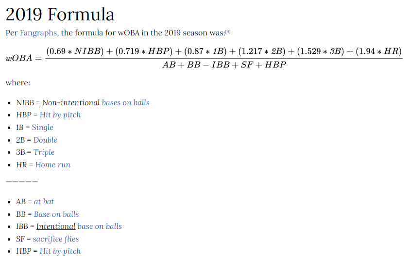

*ISO:*

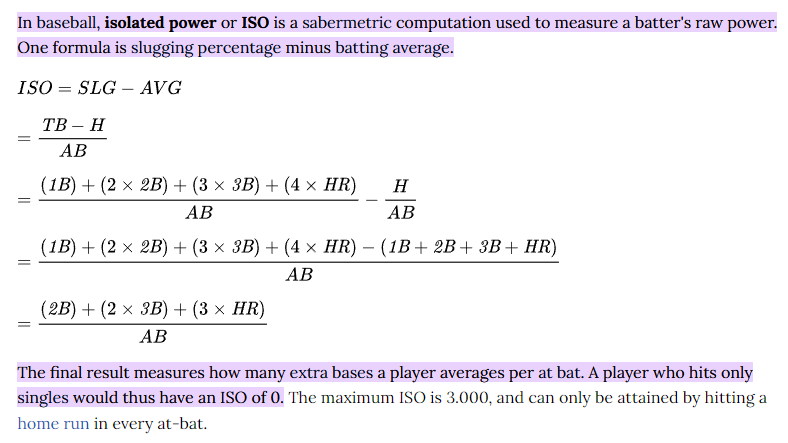

### Metric Creation

```r
#Create metrics for creating model
#consider adding the plus_statistics which are indexed to the league average
Batting_Statcast3 = Batting_Statcast2 %>%
  mutate(
    x1h = H - X2B-X3B - HR,
    ba = H/AB,
    slg = (x1h+(X2B)+(X3B*2)+(HR*3))/AB,
    obp = (H+BB+HBP)/(AB+BB+HBP+SF),
    ops = obp+slg,
    iso = ((X2B)+(X3B*2)+(HR*3))/AB,
    gpa = (obp*1.8 + slg)/4,
    ab_per_hr = ifelse(HR < 1 ,0,AB/HR),
    team_x1h = T_H - T_X2B-T_X3B - T_HR,
    #note: woba is already included in statcast
    teamW_perc = Team_W/T_G,
    teamL_perc = Team_L/T_G,
    team_AVG = T_H/T_AB,
    team_slg = (team_x1h+(T_X2B)+(T_X3B*2)+(T_HR*3))/T_AB,
    slg_share =(x1h+(X2B)+(X3B*2)+(HR*3))/ (team_x1h+(T_X2B)+(T_X3B*2)+(T_HR*3)) ,
    team_iso = ((T_X2B)+(T_X3B*2)+(T_HR*3))/AB,
    xba= as.numeric(xba),
    xslg= as.numeric(xslg),
    woba= as.numeric(woba),
    xwoba= as.numeric(xwoba),
    xobp= as.numeric(xobp),
    xiso= as.numeric(xiso),
    xbadiff= as.numeric(xbadiff),
    xslgdiff= as.numeric(xslgdiff),
    wobadif= as.numeric(wobadif),

    exit_velocity_avg= as.numeric(exit_velocity_avg),
    launch_angle_avg= as.numeric(launch_angle_avg),

    sweet_spot_percent = as.numeric(sweet_spot_percent),
    barrel_batted_rate= as.numeric(barrel_batted_rate),
    solidcontact_percent= as.numeric(solidcontact_percent),
    flareburner_percent= as.numeric(flareburner_percent),
    poorlyunder_percent= as.numeric(poorlyunder_percent),
    poorlytopped_percent= as.numeric(poorlytopped_percent),
    poorlyweak_percent= as.numeric(poorlyweak_percent),
    hard_hit_percent= as.numeric(hard_hit_percent),

    n_bolts= as.numeric(n_bolts),
    hp_to_1b= as.numeric(hp_to_1b),
    sprint_speed= as.numeric(sprint_speed)
)
#Metric for measurement (scoring using this?): https://razzball.com/points-leagues-her-legs-spreadsheet-out-before-me/
#on overage how often does x lead to a points


#RUN (+1), RBI (+1), 1B (+1), 2B (+2), 3B (+3), HR (+4), BB (+1), KO (-1), HBP (+1), SB (+2), CS (-1), SF (+1)
#WIN (+5), LOSS (-5), IP (+3), K (+1), BB (-1), SAVE (+7), BLOWN SAVE (-3), ER (-1), HIT (-1), IP (+3)

#Or create a rankings system

#Value by Position
#Fix team statistics

Batting_Statcast3
```

| New_Player_ID | playerID | player_age_avg | yearID | stint_max | G | AB | R | H | X2B | X3B | HR | RBI | SB | CS | BB | SO | IBB | HBP | SH | SF | GIDP | xba | xslg | woba | xwoba | xobp | xiso | xbadiff | xslgdiff | … |
| --- | --- | --- | --- | --- | --- | --- | --- | --- | --- | --- | --- | --- | --- | --- | --- | --- | --- | --- | --- | --- | --- | --- | --- | --- | --- | --- | --- | --- | --- | --- |
| A.907 | Michael Taylor | 30 | 2021 | 1 | 142 | 483 | 58 | 118 | 16 | 1 | 12 | 54 | 14 | 7 | 33 | 144 | 0 | 5 | 2 | 5 | 9 | 0.234 | 0.387 | 0.283 | 0.292 | 0.284 | 0.153 | -0.003 | -0.011 | … |
| Abreu698 | abreujo02 | 28 | 2015 | 1 | 154 | 613 | 88 | 178 | 34 | 3 | 30 | 101 | 0 | 0 | 39 | 140 | 11 | 15 | 0 | 1 | 16 | 0.270 | 0.456 | 0.361 | 0.339 | 0.330 | 0.186 | 0.020 | 0.046 | … |
| Abreu698 | abreujo02 | 29 | 2016 | 1 | 159 | 624 | 67 | 183 | 32 | 1 | 25 | 100 | 0 | 2 | 47 | 125 | 7 | 15 | 0 | 9 | 21 | 0.281 | 0.467 | 0.349 | 0.348 | 0.344 | 0.186 | 0.012 | 0.001 | … |
| Abreu698 | abreujo02 | 30 | 2017 | 1 | 156 | 621 | 95 | 189 | 43 | 6 | 33 | 102 | 3 | 0 | 35 | 119 | 6 | 15 | 0 | 4 | 21 | 0.289 | 0.519 | 0.377 | 0.363 | 0.342 | 0.230 | 0.015 | 0.033 | … |
| Abreu698 | abreujo02 | 31 | 2018 | 1 | 128 | 499 | 68 | 132 | 36 | 1 | 22 | 78 | 2 | 0 | 37 | 109 | 7 | 11 | 0 | 6 | 14 | 0.277 | 0.490 | 0.337 | 0.355 | 0.340 | 0.214 | -0.012 | -0.017 | … |
| Abreu698 | abreujo02 | 32 | 2019 | 1 | 159 | 634 | 85 | 180 | 38 | 1 | 33 | 123 | 2 | 2 | 36 | 152 | 4 | 13 | 0 | 10 | 24 | 0.278 | 0.516 | 0.344 | 0.358 | 0.332 | 0.237 | 0.006 | -0.013 | … |
| Abreu698 | abreujo02 | 33 | 2020 | 1 | 60 | 240 | 43 | 76 | 15 | 0 | 19 | 60 | 0 | 0 | 18 | 59 | 1 | 3 | 0 | 1 | 10 | 0.299 | 0.587 | 0.411 | 0.399 | 0.357 | 0.288 | 0.018 | 0.030 | … |
| Abreu698 | Jose Abreu | 35 | 2021 | 1 | 152 | 566 | 86 | 148 | 30 | 2 | 30 | 117 | 1 | 0 | 61 | 143 | 3 | 22 | 0 | 10 | 28 | 0.281 | 0.467 | 0.349 | 0.348 | 0.344 | 0.186 | 0.012 | 0.001 | … |
| Ackley400 | ackledu01 | 27 | 2015 | 2 | 108 | 238 | 28 | 55 | 11 | 3 | 10 | 30 | 2 | 2 | 18 | 45 | 0 | 1 | 3 | 4 | 3 | 0.252 | 0.430 | 0.305 | 0.322 | 0.306 | 0.178 | -0.021 | -0.001 | … |
| Ackley400 | ackledu01 | 28 | 2016 | 1 | 28 | 61 | 6 | 9 | 0 | 0 | 0 | 4 | 0 | 0 | 8 | 9 | 0 | 0 | 0 | 1 | 0 | 0.218 | 0.299 | 0.192 | 0.275 | 0.306 | 0.081 | -0.070 | -0.151 | … |

[output cut: 990 more lines]

```r
NA
```

### Create Model File - use current statcast metrics and lagged other variables

#### Create Player Indicators, or maybe just look-up the ones I created already

##### Create indicator for improvment or decrease in statcast stats - including speed metrics, year indicator - ball park factor = avg and lahman

###### Github and correlations

- Singles correlation to R and RBIs and SBs as well as average, same with other hit types
- Linear regression for each of the hit types to points scored

#### Runs Model 1

```r
#Linear model for value of each hit
library(caret)

Batting_Statcast3NA = na.omit(Batting_Statcast3)

y_col = Batting_Statcast3$R

x_col = (Batting_Statcast3 %>%
  select(x1h,X2B,X3B,HR,BB,HBP,SO, CS, GIDP))

datalm_R = cbind(y_col,x_col)

#Add speed variables
lm2 = train(y_col~., datalm_R, method = "lm" )

summary(lm2)
```

```
Call:
lm(formula = .outcome ~ ., data = dat)

Residuals:
    Min      1Q  Median      3Q     Max
-23.901  -2.610  -0.002   2.521  29.571

Coefficients:
            Estimate Std. Error t value Pr(>|t|)
(Intercept)  0.15570    0.14666    1.06     0.29
x1h          0.31352    0.00668   46.94  < 2e-16 ***
X2B          0.45207    0.01876   24.10  < 2e-16 ***
X3B          1.10187    0.06081   18.12  < 2e-16 ***
HR           1.01176    0.01777   56.94  < 2e-16 ***
BB           0.25557    0.00745   34.29  < 2e-16 ***
HBP          0.25574    0.02874    8.90  < 2e-16 ***
SO          -0.02063    0.00416   -4.96  7.4e-07 ***
CS           0.81031    0.05313   15.25  < 2e-16 ***
GIDP        -0.35431    0.02795  -12.67  < 2e-16 ***
---
Signif. codes:  0 ‘***’ 0.001 ‘**’ 0.01 ‘*’ 0.05 ‘.’ 0.1 ‘ ’ 1

Residual standard error: 5.31 on 4149 degrees of freedom
Multiple R-squared:  0.967, Adjusted R-squared:  0.967
F-statistic: 1.36e+04 on 9 and 4149 DF,  p-value: <2e-16
```

```r
#lm1 = train(y_col~., datalm, method = "rf" )

#lm1$modelInfo$varImp(X2B)

#lm1
```

#### Runs model with statcast variables

```r
y_col = Batting_Statcast3$R

x_col = (Batting_Statcast3 %>%
  select(x1h,X2B,X3B,HR,BB,IBB,HBP,SO, GIDP,SB,sprint_speed,exit_velocity_avg))

datalm_R = na.omit(cbind(y_col,x_col))

#Add speed variables
lm3 = train(y_col~., datalm_R, method = "lm" )

summary(lm3)
```

```
Call:
lm(formula = .outcome ~ ., data = dat)

Residuals:
    Min      1Q  Median      3Q     Max
-21.077  -2.542   0.026   2.432  25.321

Coefficients:
                  Estimate Std. Error t value Pr(>|t|)
(Intercept)       -1.91502    2.71540   -0.71     0.48
x1h                0.29219    0.00632   46.26  < 2e-16 ***
X2B                0.47448    0.01750   27.11  < 2e-16 ***
X3B                0.83559    0.05782   14.45  < 2e-16 ***
HR                 1.08071    0.01715   63.01  < 2e-16 ***
BB                 0.29336    0.00750   39.13  < 2e-16 ***
IBB               -0.53370    0.04121  -12.95  < 2e-16 ***
HBP                0.24487    0.02673    9.16  < 2e-16 ***
SO                -0.03542    0.00399   -8.88  < 2e-16 ***
GIDP              -0.22297    0.02661   -8.38  < 2e-16 ***
SB                 0.35076    0.01654   21.21  < 2e-16 ***
sprint_speed       0.57514    0.05108   11.26  < 2e-16 ***
exit_velocity_avg -0.15113    0.02948   -5.13  3.1e-07 ***
---
Signif. codes:  0 ‘***’ 0.001 ‘**’ 0.01 ‘*’ 0.05 ‘.’ 0.1 ‘ ’ 1

Residual standard error: 4.93 on 4108 degrees of freedom
Multiple R-squared:  0.972, Adjusted R-squared:  0.972
F-statistic: 1.17e+04 on 12 and 4108 DF,  p-value: <2e-16
```

#### RBI Model

```r
y_col = Batting_Statcast3$RBI

x_col = Batting_Statcast3 %>%
  select(x1h,X2B,X3B,HR,BB,HBP,SO, CS, GIDP)

datalm_RBI = cbind(y_col,x_col)

lm4 = train(y_col~., datalm_RBI, method = "lm" )

summary(lm4)
```

```
Call:
lm(formula = .outcome ~ ., data = dat)

Residuals:
    Min      1Q  Median      3Q     Max
-29.625  -2.718  -0.265   2.682  31.116

Coefficients:
            Estimate Std. Error t value Pr(>|t|)
(Intercept)  0.40970    0.16129    2.54    0.011 *
x1h          0.20959    0.00735   28.53  < 2e-16 ***
X2B          0.52029    0.02063   25.22  < 2e-16 ***
X3B          0.26888    0.06688    4.02  5.9e-05 ***
HR           1.65779    0.01954   84.82  < 2e-16 ***
BB           0.03506    0.00820    4.28  1.9e-05 ***
HBP         -0.03809    0.03161   -1.21    0.228
SO          -0.00212    0.00458   -0.46    0.643
CS          -0.74169    0.05843  -12.69  < 2e-16 ***
GIDP         0.36721    0.03075   11.94  < 2e-16 ***
---
Signif. codes:  0 ‘***’ 0.001 ‘**’ 0.01 ‘*’ 0.05 ‘.’ 0.1 ‘ ’ 1

Residual standard error: 5.84 on 4149 degrees of freedom
Multiple R-squared:  0.96,  Adjusted R-squared:  0.96
F-statistic: 1.1e+04 on 9 and 4149 DF,  p-value: <2e-16
```

#### RBI Model - using statcast variables

```r
Batting_Statcast3NA = na.omit(Batting_Statcast3)

y_col = Batting_Statcast3NA$RBI

x_col = (Batting_Statcast3NA %>%
  select(x1h,X2B,X3B,HR,IBB, CS, GIDP,sprint_speed,exit_velocity_avg))

datalm_R = cbind(y_col,x_col)

#Add speed variables
lm5 = train(y_col~., datalm_R, method = "lm" )

summary(lm5)
```

```
Call:
lm(formula = .outcome ~ ., data = dat)

Residuals:
    Min      1Q  Median      3Q     Max
-25.842  -3.535  -0.146   3.425  28.420

Coefficients:
                  Estimate Std. Error t value Pr(>|t|)
(Intercept)        6.54667    5.40225    1.21    0.226
x1h                0.20248    0.00877   23.09  < 2e-16 ***
X2B                0.53770    0.02442   22.02  < 2e-16 ***
X3B                0.39261    0.08179    4.80  1.7e-06 ***
HR                 1.63313    0.02036   80.22  < 2e-16 ***
IBB                0.24629    0.05311    4.64  3.7e-06 ***
CS                -0.59502    0.07270   -8.18  4.1e-16 ***
GIDP               0.33487    0.03815    8.78  < 2e-16 ***
sprint_speed      -0.51354    0.09674   -5.31  1.2e-07 ***
exit_velocity_avg  0.09209    0.05506    1.67    0.095 .
---
Signif. codes:  0 ‘***’ 0.001 ‘**’ 0.01 ‘*’ 0.05 ‘.’ 0.1 ‘ ’ 1

Residual standard error: 6.41 on 2810 degrees of freedom
Multiple R-squared:  0.95,  Adjusted R-squared:  0.95
F-statistic: 5.91e+03 on 9 and 2810 DF,  p-value: <2e-16
```

#### HR Model - using statcast variables

```r
y_col = Batting_Statcast3$HR

x_col = (Batting_Statcast3 %>%
  select(x1h,X2B,IBB, GIDP,exit_velocity_avg,barrel_batted_rate,sweet_spot_percent,launch_angle_avg, solidcontact_percent))

datalm_R = na.omit(cbind(y_col,x_col))

#Add speed variables
lm6 = train(y_col~., datalm_R, method = "lm" )

summary(lm6)
```

```
Call:
lm(formula = .outcome ~ ., data = dat)

Residuals:
    Min      1Q  Median      3Q     Max
-24.280  -2.715  -0.027   2.268  27.602

Coefficients:
                     Estimate Std. Error t value Pr(>|t|)
(Intercept)           8.76961    2.96153    2.96   0.0031 **
x1h                   0.02696    0.00544    4.95  7.6e-07 ***
X2B                   0.38149    0.01575   24.22  < 2e-16 ***
IBB                   0.61270    0.03545   17.28  < 2e-16 ***
GIDP                  0.24687    0.02373   10.40  < 2e-16 ***
exit_velocity_avg    -0.09874    0.03525   -2.80   0.0051 **
barrel_batted_rate    0.81495    0.02299   35.45  < 2e-16 ***
sweet_spot_percent   -0.19389    0.01338  -14.49  < 2e-16 ***
launch_angle_avg      0.12558    0.01373    9.15  < 2e-16 ***
solidcontact_percent  0.15524    0.03103    5.00  5.9e-07 ***
---
Signif. codes:  0 ‘***’ 0.001 ‘**’ 0.01 ‘*’ 0.05 ‘.’ 0.1 ‘ ’ 1

Residual standard error: 4.78 on 4148 degrees of freedom
Multiple R-squared:  0.763, Adjusted R-squared:  0.763
F-statistic: 1.48e+03 on 9 and 4148 DF,  p-value: <2e-16
```

#### SB Model - using statcast variables

```r
#Can't steal after a double hehe

y_col = Batting_Statcast3$SB

x_col = (Batting_Statcast3 %>%
  select(x1h,X3B, CS, GIDP,sprint_speed, n_bolts, BB
      ))

datalm_R = na.omit(cbind(y_col,x_col))

#Add speed variables
lm7 = train(y_col~., datalm_R, method = "lm" )

summary(lm7)
```

```
Call:
lm(formula = .outcome ~ ., data = dat)

Residuals:
    Min      1Q  Median      3Q     Max
-28.263  -1.514   0.075   0.964  29.592

Coefficients:
             Estimate Std. Error t value Pr(>|t|)
(Intercept)  -4.16217    1.03034   -4.04  5.5e-05 ***
x1h           0.04050    0.00408    9.92  < 2e-16 ***
X3B           0.19449    0.04359    4.46  8.4e-06 ***
CS            1.52281    0.03915   38.89  < 2e-16 ***
GIDP         -0.12744    0.02000   -6.37  2.1e-10 ***
sprint_speed  0.14095    0.03873    3.64  0.00028 ***
n_bolts       0.17117    0.00630   27.18  < 2e-16 ***
BB            0.01020    0.00413    2.47  0.01353 *
---
Signif. codes:  0 ‘***’ 0.001 ‘**’ 0.01 ‘*’ 0.05 ‘.’ 0.1 ‘ ’ 1

Residual standard error: 3.62 on 3701 degrees of freedom
Multiple R-squared:  0.705, Adjusted R-squared:  0.704
F-statistic: 1.26e+03 on 7 and 3701 DF,  p-value: <2e-16
```

#### BA Model - using statcast variables

```r
y_col = Batting_Statcast3$gpa

x_col = (Batting_Statcast3 %>%
  select(x1h,
         #X3B,
         HR,BB,SO,GIDP,flareburner_percent, exit_velocity_avg,launch_angle_avg,sprint_speed, sweet_spot_percent, barrel_batted_rate, poorlytopped_percent, poorlyweak_percent,     hard_hit_percent,PF_SC
      ))

datalm_R = na.omit(cbind(y_col,x_col))

#Add speed variables
lm8 = train(y_col~., datalm_R, method = "lm" )

summary(lm8)
```

```
Call:
lm(formula = .outcome ~ ., data = dat)

Residuals:
    Min      1Q  Median      3Q     Max
-0.1788 -0.0139  0.0009  0.0167  0.1846

Coefficients:
                      Estimate Std. Error t value Pr(>|t|)
(Intercept)          -1.75e-01   3.46e-02   -5.06  4.3e-07 ***
x1h                   5.97e-04   2.98e-05   20.03  < 2e-16 ***
HR                    1.31e-03   1.02e-04   12.82  < 2e-16 ***
BB                    6.08e-04   4.01e-05   15.16  < 2e-16 ***
SO                   -5.27e-04   2.27e-05  -23.27  < 2e-16 ***
GIDP                 -8.46e-04   1.52e-04   -5.57  2.6e-08 ***
flareburner_percent   1.88e-03   1.16e-04   16.21  < 2e-16 ***
exit_velocity_avg     6.90e-04   3.77e-04    1.83    0.067 .
launch_angle_avg      1.12e-03   1.41e-04    7.99  1.7e-15 ***
sprint_speed          4.13e-03   2.88e-04   14.32  < 2e-16 ***
sweet_spot_percent    1.08e-03   9.68e-05   11.17  < 2e-16 ***
barrel_batted_rate    2.79e-03   1.89e-04   14.81  < 2e-16 ***
poorlytopped_percent  1.10e-03   1.17e-04    9.47  < 2e-16 ***
poorlyweak_percent    1.12e-03   2.04e-04    5.51  3.9e-08 ***
hard_hit_percent      6.33e-04   1.08e-04    5.86  5.0e-09 ***
PF_SC                 2.71e-02   1.02e-02    2.65    0.008 **
---
Signif. codes:  0 ‘***’ 0.001 ‘**’ 0.01 ‘*’ 0.05 ‘.’ 0.1 ‘ ’ 1

Residual standard error: 0.0286 on 4105 degrees of freedom
Multiple R-squared:  0.676, Adjusted R-squared:  0.675
F-statistic:  571 on 15 and 4105 DF,  p-value: <2e-16
```

#### Worth of each stat

```r
SB_worth = 162/max(Batting_Statcast3$SB)

HR_worth = 162/max(Batting_Statcast3$HR)

ba_worth = 162/max(Batting_Statcast3$ba)/max(Batting_Statcast3$gpa)

RBI_worth = 162/max(Batting_Statcast3$RBI)

R_worth = 162/max(Batting_Statcast3$R)

Worth_vector = cbind(SB_worth,HR_worth ,ba_worth,RBI_worth,R_worth)
```

#### Coefficent Gathering

```r
BA_model= cbind(as.data.frame(attr(lm8$terms , "term.labels")),as.data.frame(summary(lm8)$coefficients)[-1,1])
names(BA_model) = c("Variable","Coef")

BA_model2=
BA_model %>%
  mutate(
  Worth=  Coef* ba_worth
  )


RUNS_model= cbind(as.data.frame(attr(lm3$terms , "term.labels")),as.data.frame(summary(lm3)$coefficients)[-1,1])
names(RUNS_model) = c("Variable","Coef")

RUNS_model2=
RUNS_model %>%
  mutate(
  Worth=  Coef* R_worth
  )



SB_model= cbind(as.data.frame(attr(lm7$terms , "term.labels")),as.data.frame(summary(lm7)$coefficients)[-1,1])
names(SB_model) = c("Variable","Coef")

SB_model2=
SB_model %>%
  mutate(
  Worth=  Coef* SB_worth
  )


HR_model= cbind(as.data.frame(attr(lm6$terms , "term.labels")),as.data.frame(summary(lm6)$coefficients)[-1,1])
names(HR_model) = c("Variable","Coef")

HR_model2=
HR_model %>%
  mutate(
  Worth=  Coef* HR_worth
  )


RBI_model= cbind(as.data.frame(attr(lm5$terms , "term.labels")),as.data.frame(summary(lm5)$coefficients)[-1,1])
names(RBI_model) = c("Variable","Coef")

RBI_model2=
RBI_model %>%
  mutate(
  Worth=  Coef* RBI_worth
  )


Total_worth = rbind(BA_model2,SB_model2,HR_model2,RBI_model2,RBI_model2)

Sum_worth =
Total_worth %>%
  group_by(Variable) %>%
  summarise(add_worth = sum(Worth))
```

#Re-Assess Hitting Score Metric

```r
defaultW <- getOption("warn")
options(warn = -1)
#Create metrics for creating model
#consider adding the plus_statistics which are indexed to the league average
Batting_Statcast3 = Batting_Statcast2 %>%
  mutate(
    x1h = H - X2B-X3B - HR,
    ba = H/AB,
    slg = (x1h+(X2B)+(X3B*2)+(HR*3))/AB,
    obp = (H+BB+HBP)/(AB+BB+HBP+SF),
    ops = obp+slg,
    iso = ((X2B)+(X3B*2)+(HR*3))/AB,
    gpa = (obp*1.8 + slg)/4,
    ab_per_hr = ifelse(HR < 1 ,0,AB/HR),
    team_x1h = T_H - T_X2B-T_X3B - T_HR,
    HBP_perc = HBP/AB,
    BB_perc = BB/AB,
    IBB_perc = IBB/AB,
    RBI_perc = RBI/AB,
    HR_perc = HR/AB,
    SO_perc = SO/AB,
    CS_perc = CS/G,
    SB_perc = SB/G,
    GIDP_perc = GIDP/AB,
    #note: woba is already included in statcast
    teamW_perc = Team_W/T_G,
    teamL_perc = Team_L/T_G,
    team_AVG = T_H/T_AB,
    team_slg = (team_x1h+(T_X2B)+(T_X3B*2)+(T_HR*3))/T_AB,
    slg_share =(x1h+(X2B)+(X3B*2)+(HR*3))/ (team_x1h+(T_X2B)+(T_X3B*2)+(T_HR*3)) ,
    team_iso = ((T_X2B)+(T_X3B*2)+(T_HR*3))/AB,
    xba= as.numeric(xba),
    xslg= as.numeric(xslg),
    woba= as.numeric(woba),
    xwoba= as.numeric(xwoba),
    xobp= as.numeric(xobp),
    xiso= as.numeric(xiso),
    xbadiff= as.numeric(xbadiff),
    xslgdiff= as.numeric(xslgdiff),
    wobadif= as.numeric(wobadif),

    exit_velocity_avg= as.numeric(exit_velocity_avg),
    launch_angle_avg= as.numeric(launch_angle_avg),

    sweet_spot_percent = as.numeric(sweet_spot_percent),
    barrel_batted_rate= as.numeric(barrel_batted_rate),
    solidcontact_percent= as.numeric(solidcontact_percent),
    flareburner_percent= as.numeric(flareburner_percent),
    poorlyunder_percent= as.numeric(poorlyunder_percent),
    poorlytopped_percent= as.numeric(poorlytopped_percent),
    poorlyweak_percent= as.numeric(poorlyweak_percent),
    hard_hit_percent= as.numeric(hard_hit_percent),

    n_bolts= as.numeric(n_bolts),
    hp_to_1b= as.numeric(hp_to_1b),
    sprint_speed= as.numeric(sprint_speed),
    hitting_score1 = (1*R)+(1*x1h)+(2*X2B)+(3*X3B)+(4*HR) +
  (BB*0.25) + (SO*-0.50) + (HBP *0.25) + (SB *1.5) + (CS*-0.5) + (SF *1) + (GIDP * -1),
    hitting_score2 = (SB_worth*SB)+(HR_worth*HR)+(RBI_worth*RBI)+(ba_worth*ba)+(R_worth*R)+(barrel_batted_rate*4.66516154275165)+
(BB*0.55560592809121)+
(CS*2.52944003301411)+
(exit_velocity_avg*0.552642412438484)+
(flareburner_percent*1.63737059222312)+
(GIDP*0.425322605140042)+
(hard_hit_percent*0.550192443423582)+
(HR*5.11825743321138)+
(IBB*2.28231931472431)+
(launch_angle_avg*1.32159510336231)+
(ifelse(is.na(n_bolts),0,n_bolts*0.447239403616531))+
(PF_SC*23.563526411751)+
(poorlytopped_percent*0.959418886528)+
(poorlyweak_percent*0.975982986566501)+
(SO*-0.458435935570646)+
(solidcontact_percent*0.426263636787222)+
(ifelse(is.na(sprint_speed),26*2.70339379878721,sprint_speed*2.70339379878721))+
(sweet_spot_percent*0.407979625526337)+
(x1h*1.19175976745105)+
(X2B*2.35736214738333)+
(X3B*1.46459272393738)
)


options(warn = defaultW)
```

### FIgure out average decrease in stats YoY for projections?

### Lagged Variables

```r
names(Batting_Statcast3)
```

```
  [1] "New_Player_ID"        "playerID"             "player_age_avg"
  [4] "yearID"               "stint_max"            "G"
  [7] "AB"                   "R"                    "H"
 [10] "X2B"                  "X3B"                  "HR"
 [13] "RBI"                  "SB"                   "CS"
 [16] "BB"                   "SO"                   "IBB"
 [19] "HBP"                  "SH"                   "SF"
 [22] "GIDP"                 "xba"                  "xslg"
 [25] "woba"                 "xwoba"                "xobp"
 [28] "xiso"                 "xbadiff"              "xslgdiff"
 [31] "wobadif"              "exit_velocity_avg"    "launch_angle_avg"
 [34] "sweet_spot_percent"   "barrel_batted_rate"   "solidcontact_percent"
 [37] "flareburner_percent"  "poorlyunder_percent"  "poorlytopped_percent"
 [40] "poorlyweak_percent"   "hard_hit_percent"     "n_bolts"
 [43] "hp_to_1b"             "sprint_speed"         "lgID"
```

[output cut: 31 more lines]

#### Create Model File

```r
#Indicators

player_ind = read_csv(
  "Player_ind.csv"
)
Batting_Statcast4 <- sqldf("
    select a.*, b.IND from
    Batting_Statcast3 a, player_ind b
    on a.New_Player_ID = b.New_Player_ID
                           ")


Batting_Statcast_MF_Init =
Batting_Statcast4 %>%
  select(
    hitting_score2,c(3,23,24,26:28,32,44,84:95,96,115,117,124:139)
  )

skim(Batting_Statcast_MF_Init)
```

```
-- Data Summary ------------------------
                           Values
Name                       Batting_Statcast_MF_Init
Number of rows             4159
Number of columns          40
_______________________
Column type frequency:
  numeric                  40
________________________
Group variables            None

-- Variable type: numeric -----------------------------------------------------------
# A tibble: 40 x 11
   skim_variable     n_missing complete_rate      mean        sd       p0      p25
 * <chr>                 <int>         <dbl>     <dbl>     <dbl>    <dbl>    <dbl>
```

[output cut: 82 more lines]

#### Impute NAs to be average for that player potentally, right now just see base model

```r
set.seed(100)  # For reproducibility
# Create index for testing and training data
inTrain <- createDataPartition(y = Batting_Statcast_MF_Init$hitting_score2, p = 0.8, list = FALSE)
# subset power_plant data to training
tr <- Batting_Statcast_MF_Init[inTrain,]
# subset the rest to test
 te <- Batting_Statcast_MF_Init[-inTrain,]
```

*cleaning documentations:* https://www.kaggle.com/pelkoja/visual-xgboost-tuning-with-caret

```r
X_train = (tr %>% select(-hitting_score2))
y_train = tr$hitting_score2
X_test = (te %>% select(-hitting_score2))
y_test = te$hitting_score2


treat_plan <- vtreat::designTreatmentsZ(
  dframe = tr, # training data
  varlist = colnames(tr) %>% .[. != "hitting_score1"], # input variables = all training data columns, except random
  codeRestriction = c("clean", "isBAD", "lev"), # derived variables types (drop cat_P)
  verbose = FALSE) # suppress messages
```

- clean stands for cleaned numerical variable, isBAD indicates that a value replacement has occurred (which indicates a missing value in this case), and lev is a binary indicator whether a particular value of that categorical variable was present.

```r
score_frame <- treat_plan$scoreFrame %>%
  select(varName, origName, code)

head(score_frame)
```

|  | varName | origName | code |
| --- | --- | --- | --- |
| 1 | hitting_score2 | hitting_score2 | clean |
| 2 | player_age_avg | player_age_avg | clean |
| 3 | xba | xba | clean |
| 4 | xslg | xslg | clean |
| 5 | xwoba | xwoba | clean |
| 6 | xobp | xobp | clean |

#test model without using log variable perhaps

```r
tr_treated <- vtreat::prepare(treat_plan, tr)
te_treated <- vtreat::prepare(treat_plan, te)


#Convert dependant to log score
tr_treated$hitting_score2 <- log(tr_treated$hitting_score2)

dim(tr_treated)
```

```
[1] 3328   56
```

#### In addition, we’ll be taking out a hold-out set. This is because looking at the cross-validated RMSE can give over-optimistic view on the model performance, and we can now test the model performance with unseen data without having to submit anything to Kaggle. In order not to sacrifice too much training data, we’ll be taking an 80/20 split with `dplyr`:

```r
tr_holdout <- dplyr::sample_frac(tr_treated, 0.2)
hid <- as.numeric(rownames(tr_holdout))
tr_treated <- tr_treated[-hid, ]
```

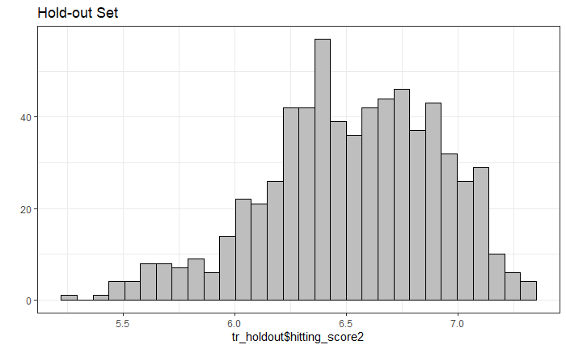

```r
ggplot2::qplot(tr_holdout$hitting_score2, main="Hold-out Set") + geom_histogram(colour="black", fill="grey") + theme_bw()
```

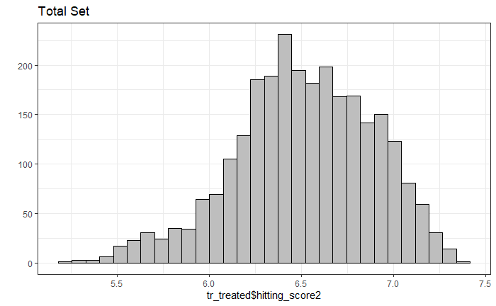

```r
ggplot2::qplot(tr_treated$hitting_score2, main="Total Set") + geom_histogram(colour="black", fill="grey") + theme_bw()
```

##### To keep things simple with modeling, we’ll turn the traninig data into simple input variables for `caret::train`, dropping the response variable and converting the data frame to a matrix:

```r
input_x <- as.matrix(select(tr_treated, -hitting_score2))
input_y <- tr_treated$hitting_score2
```

###### Linear Model first

- Look at value with the highest correlation

```r
(mcor <- tr_treated %>%
{cor(select(., -hitting_score2), .$hitting_score2, method = "spearman")} %>%
    .[. == max(.), ])
```

```
  xslg
0.7243
```

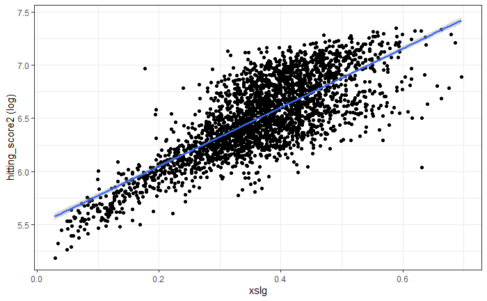

```r
lin_x <- tr_treated[, which(names(tr_treated) == names(mcor))]
lin_y <- tr_treated$hitting_score2

ggplot2::ggplot() +
  aes(x = lin_x, y = lin_y) +
  geom_jitter() +
  xlab(names(mcor)) +
  ylab("hitting_score2 (log)") +
  theme_bw() +
  geom_smooth(method = "lm")
```

##### And train a linear model with lm() using expected slugging as the explanatory variable:

```r
summary(linear_base)
```

```
Call:
lm(formula = paste0("hitting_score2 ~ ", names(mcor)), data = tr_treated)

Residuals:
    Min      1Q  Median      3Q     Max
-1.2091 -0.1552 -0.0131  0.1576  0.9816

Coefficients:
            Estimate Std. Error t value Pr(>|t|)
(Intercept)   5.4949     0.0165     332   <2e-16 ***
xslg          2.7727     0.0433      64   <2e-16 ***
---
Signif. codes:  0 ‘***’ 0.001 ‘**’ 0.01 ‘*’ 0.05 ‘.’ 0.1 ‘ ’ 1

Residual standard error: 0.236 on 2660 degrees of freedom
Multiple R-squared:  0.606, Adjusted R-squared:  0.606
F-statistic: 4.09e+03 on 1 and 2660 DF,  p-value: <2e-16
```

#### XGBoost with Default Hyperparameters

```r
grid_default <- expand.grid(
  nrounds = 100,
  max_depth = 6,
  eta = 0.3,
  gamma = 0,
  colsample_bytree = 1,
  min_child_weight = 1,
  subsample = 1
)

train_control <- caret::trainControl(
  method = "none",
  verboseIter = FALSE, # no training log
  allowParallel = TRUE # FALSE for reproducible results
)

xgb_base <- caret::train(
  x = input_x,
  y = input_y,
  trControl = train_control,
  tuneGrid = grid_default,
  method = "xgbTree",
  verbose = TRUE
)
```

##### Next, we build tuning grid for caret to explore between different hyperparameter values. To get started we’re using some suggestions from: https://www.slideshare.net/OwenZhang2/tips-for-data-science-competitions/14.

```r
defaultW <- getOption("warn")
options(warn = -1)



# maximum number of trees
nrounds <- 1000

# note to start nrounds from 200, as smaller learning rates result in errors so
# big with lower starting points that they'll mess the scales
tune_grid <- expand.grid(
  nrounds = seq(from = 200, to = nrounds, by = 50),
  eta = c(0.025, 0.05, 0.1, 0.2, 0.3),
  max_depth = c(2, 4, 5, 6, 8, 10),
  gamma = 0,
  colsample_bytree = 1,
  min_child_weight = 1,
  subsample = 1
)

tune_control <- caret::trainControl(
  method = "cv", # cross-validation
  number = 5, # with n folds
  #index = createFolds(tr_treated$Id_clean), # fix the folds
  verboseIter = FALSE, # no training log
  allowParallel = TRUE # FALSE for reproducible results
)



xgb_tune <- caret::train(
  x = input_x,
  y = input_y,
  trControl = tune_control,
  tuneGrid = tune_grid,
  method = "xgbTree",
  verbose = TRUE
)
```

[output not shown]

[output cut: 1337 more lines]

[output not shown]

#### plot for data

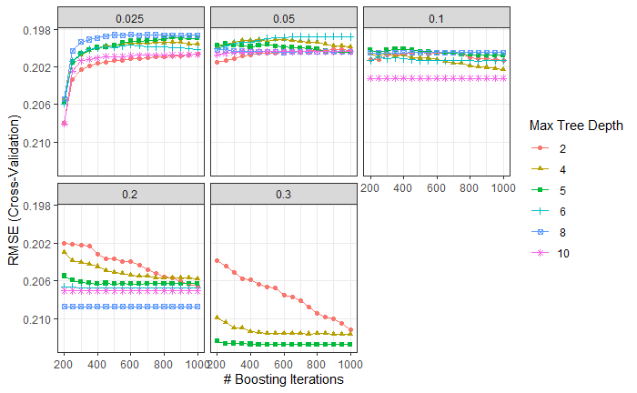

```r
# helper function for the plots
tuneplot <- function(x, probs = .90) {
  ggplot(x) +
    coord_cartesian(ylim = c(quantile(x$results$RMSE, probs = probs), min(x$results$RMSE))) +
    theme_bw()
}

tuneplot(xgb_tune)
```

```r
xgb_tune$bestTune
```

|  | nrounds | max_depth | eta | gamma | colsample_bytree | min_child_weight | subsample |
| --- | --- | --- | --- | --- | --- | --- | --- |
| 77 | 600 | 8 | 0.025 | 0 | 1 | 1 | 1 |

```r
NA
```

#### Second Tuning: Maximum Depth and Minimum Child Weight

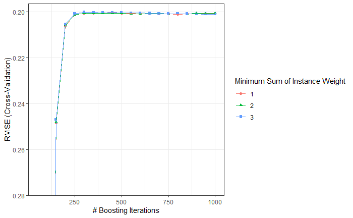

```r
tune_grid2 <- expand.grid(
  nrounds = seq(from = 50, to = nrounds, by = 50),
  eta = xgb_tune$bestTune$eta,
  max_depth = ifelse(xgb_tune$bestTune$max_depth == 2,
    c(xgb_tune$bestTune$max_depth:4),
    xgb_tune$bestTune$max_depth - 1:xgb_tune$bestTune$max_depth + 1),
  gamma = 0,
  colsample_bytree = 1,
  min_child_weight = c(1, 2, 3),
  subsample = 1
)

xgb_tune2 <- caret::train(
  x = input_x,
  y = input_y,
  trControl = tune_control,
  tuneGrid = tune_grid2,
  method = "xgbTree",
  verbose = TRUE
)

tuneplot(xgb_tune2)
```

```r
xgb_tune2$bestTune
```

|  | nrounds | max_depth | eta | gamma | colsample_bytree | min_child_weight | subsample |
| --- | --- | --- | --- | --- | --- | --- | --- |
| 46 | 300 | 8 | 0.025 | 0 | 1 | 3 | 1 |

##### Third Tuning: Column and Row Sampling

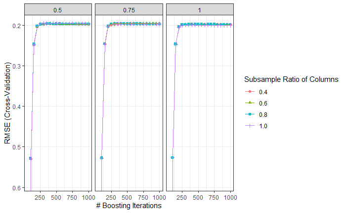

```r
tune_grid3 <- expand.grid(
  nrounds = seq(from = 50, to = nrounds, by = 50),
  eta = xgb_tune$bestTune$eta,
  max_depth = xgb_tune2$bestTune$max_depth,
  gamma = 0,
  colsample_bytree = c(0.4, 0.6, 0.8, 1.0),
  min_child_weight = xgb_tune2$bestTune$min_child_weight,
  subsample = c(0.5, 0.75, 1.0)
)

xgb_tune3 <- caret::train(
  x = input_x,
  y = input_y,
  trControl = tune_control,
  tuneGrid = tune_grid3,
  method = "xgbTree",
  verbose = TRUE
)

tuneplot(xgb_tune3, probs = .95)
```

```r
xgb_tune3$bestTune
```

|  | nrounds | max_depth | eta | gamma | colsample_bytree | min_child_weight | subsample |
| --- | --- | --- | --- | --- | --- | --- | --- |
| 188 | 400 | 8 | 0.025 | 0 | 1 | 3 | 0.5 |

```r
NA
```

##### Fourth Tuning: Gamma

Next, we again pick the best values from previous step, and now will see whether changing the gamma has any effect on the model fit:

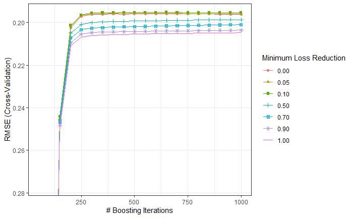

```r
tune_grid4 <- expand.grid(
  nrounds = seq(from = 50, to = nrounds, by = 50),
  eta = xgb_tune$bestTune$eta,
  max_depth = xgb_tune2$bestTune$max_depth,
  gamma = c(0, 0.05, 0.1, 0.5, 0.7, 0.9, 1.0),
  colsample_bytree = xgb_tune3$bestTune$colsample_bytree,
  min_child_weight = xgb_tune2$bestTune$min_child_weight,
  subsample = xgb_tune3$bestTune$subsample
)

xgb_tune4 <- caret::train(
  x = input_x,
  y = input_y,
  trControl = tune_control,
  tuneGrid = tune_grid4,
  method = "xgbTree",
  verbose = TRUE
)

tuneplot(xgb_tune4)
```

```r
xgb_tune4$bestTune
```

|  | nrounds | max_depth | eta | gamma | colsample_bytree | min_child_weight | subsample |
| --- | --- | --- | --- | --- | --- | --- | --- |
| 53 | 650 | 8 | 0.025 | 0.1 | 1 | 3 | 0.5 |

##### Fifth Tuning: Reducing the Learning Rate

Now, we have tuned the hyperparameters and can start reducing the learning rate to get to the final model:

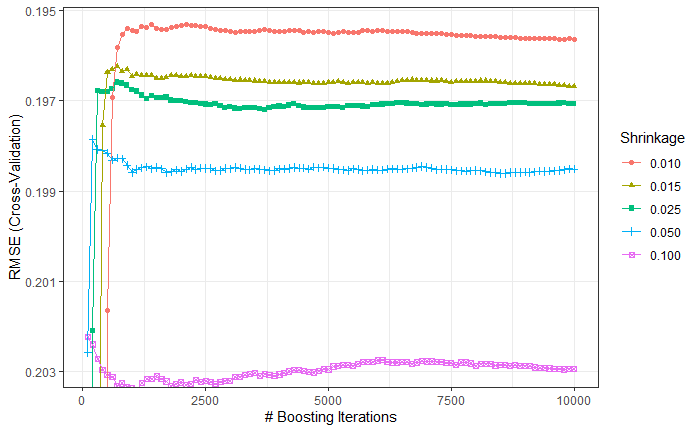

```r
tune_grid5 <- expand.grid(
  nrounds = seq(from = 100, to = 10000, by = 100),
  eta = c(0.01, 0.015, 0.025, 0.05, 0.1),
  max_depth = xgb_tune2$bestTune$max_depth,
  gamma = xgb_tune4$bestTune$gamma,
  colsample_bytree = xgb_tune3$bestTune$colsample_bytree,
  min_child_weight = xgb_tune2$bestTune$min_child_weight,
  subsample = xgb_tune3$bestTune$subsample
)

xgb_tune5 <- caret::train(
  x = input_x,
  y = input_y,
  trControl = tune_control,
  tuneGrid = tune_grid5,
  method = "xgbTree",
  verbose = TRUE
)

tuneplot(xgb_tune5)
```

```r
xgb_tune5$bestTune
```

|  | nrounds | max_depth | eta | gamma | colsample_bytree | min_child_weight | subsample |
| --- | --- | --- | --- | --- | --- | --- | --- |
| 14 | 1400 | 8 | 0.01 | 0.1 | 1 | 3 | 0.5 |

#### Fitting Final Model

```r
(final_grid <- expand.grid(
  nrounds = xgb_tune5$bestTune$nrounds,
  eta = xgb_tune5$bestTune$eta,
  max_depth = xgb_tune5$bestTune$max_depth,
  gamma = xgb_tune5$bestTune$gamma,
  colsample_bytree = xgb_tune5$bestTune$colsample_bytree,
  min_child_weight = xgb_tune5$bestTune$min_child_weight,
  subsample = xgb_tune5$bestTune$subsample
))
```

| nrounds | eta | max_depth | gamma | colsample_bytree | min_child_weight | subsample |
| --- | --- | --- | --- | --- | --- | --- |
| 1400 | 0.01 | 8 | 0.1 | 1 | 3 | 0.5 |

```r
(xgb_model <- caret::train(
  x = input_x,
  y = input_y,
  trControl = train_control,
  tuneGrid = final_grid,
  method = "xgbTree",
  verbose = TRUE
))
```

```
eXtreme Gradient Boosting

2662 samples
  55 predictor

No pre-processing
Resampling: None
```

#### Score model

```r
holdout_x <- select(tr_holdout, -hitting_score2)
holdout_y <- tr_holdout$hitting_score2

(linear_base_rmse <- ModelMetrics::rmse(holdout_y, predict(linear_base, newdata = holdout_x)))
```

```
[1] 0.2392
```

```r
(xgb_base_rmse <- ModelMetrics::rmse(holdout_y, predict(xgb_base, newdata = holdout_x)))
```

```
[1] 0.09957
```

```r
(xgb_model_rmse <- ModelMetrics::rmse(holdout_y, predict(xgb_model, newdata = holdout_x)))
```

```
[1] 0.1269
```

#### Check on Test Data

```r
y_pred_test <- predict(xgb_model, data.matrix(te_treated))

test_stats= cbind(log(te_treated$hitting_score2),y_pred_test)

test_statsR2 = cor(test_stats[,1],test_stats[,2])^2

print(test_statsR2)
```

```
[1] 0.7545
```

```r
y_pred_train <- predict(xgb_model, data.matrix(tr_treated))

train_stats = cbind((tr_treated$hitting_score2),y_pred_train)

train_statsR2 = cor(train_stats[,1],train_stats[,2])^2

print(train_statsR2)
```

```
[1] 0.9315
```

```r
holdout_x <- select(tr_treated, -hitting_score2)
holdout_y <- tr_treated$hitting_score2

(xgb_model_rmse <- ModelMetrics::rmse(holdout_y, predict(xgb_model, newdata = holdout_x)))
```

```
[1] 0.101
```

```r
holdout_x <- select(te_treated, -hitting_score2)
holdout_y <- log(te_treated$hitting_score2)

(xgb_model_rmse <- ModelMetrics::rmse(holdout_y, predict(xgb_model, newdata = holdout_x)))
```

```
[1] 0.1891
```

### Additional Metrics to check

```r
varImp(xgb_model,scale=FALSE)
```

```
xgbTree variable importance

  only 20 most important variables shown (out of 55)
```

|  | Overall |
| --- | --- |
| xslg | 0.217293 |
| xba | 0.154191 |
| xwoba | 0.141394 |
| lag_slg_share | 0.065048 |
| team_AVG | 0.031938 |
| xobp | 0.029122 |
| exit_velocity_avg | 0.027975 |
| IND | 0.025826 |
| sprint_speed | 0.024625 |
| xiso | 0.024502 |

[output cut: 10 more lines]

### Plot Train Results

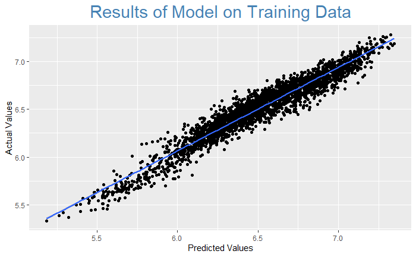

```r
par(mfrow=c(2,1))

ggplot2::ggplot() +
  aes(x = train_stats[,1], y = train_stats[,2]) +
  geom_jitter() +
  xlab("Predicted Values") +
  ylab("Actual Values") +
  ggtitle("Results of Model on Training Data")+
  theme(plot.title = element_text(hjust = 0.5,size = 22,color ="Steel Blue"))+
  geom_smooth(method = "lm")
```

### Plot Test Results

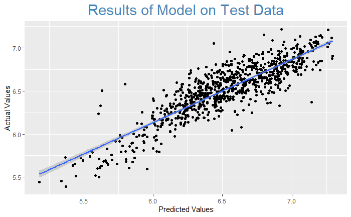

```r
ggplot2::ggplot() +
  aes(x = test_stats[,1], y = test_stats[,2]) +
  geom_jitter() +
  xlab("Predicted Values") +
  ylab("Actual Values") +
  ggtitle("Results of Model on Test Data")+
  theme(plot.title = element_text(hjust = 0.5,size = 22,color ="steel blue"))+
  geom_smooth(method = "lm")
```